# eGARCH Model - Gold (ozt) / U.S. Dollar (XAUUSD) volatility and return rates prediction

Piotr Wieczorek

2023-10-12

```r
rm(list=ls())
```

## Libraries

```r
library(xts)
library(quantmod)
library(tidyverse)
library(lubridate)
library(tseries)
library(rugarch)
library(lmtest)
library(moments)
library(forecast)
```

## Reading and cleaning the data

```r
df <- read.csv('xauusd_d.csv')
```

### Selecting only relevant columns

```r
df <- df %>%
  select(Data, Zamkniecie)
```

### Renaming columns

```r
colnames(df) <- c("Date","Close")
```

```r
head(df)
```

```
##         Date   Close
## 1 2020-03-02 1589.37
## 2 2020-03-03 1640.92
## 3 2020-03-04 1636.97
## 4 2020-03-05 1672.21
## 5 2020-03-06 1673.21
## 6 2020-03-09 1678.80
```

### Changing Date column to date format

```r
df <- df %>%
  mutate(Date = lubridate::ymd(Date))
```

### Changing the dataframe to an xts object

```r
data_xts <- xts(df$Close,order.by=df$Date)
```

```r
head(data_xts,10)
```

```
##               [,1]
## 2020-03-02 1589.37
## 2020-03-03 1640.92
## 2020-03-04 1636.97
## 2020-03-05 1672.21
## 2020-03-06 1673.21
## 2020-03-09 1678.80
## 2020-03-10 1650.35
## 2020-03-11 1637.57
## 2020-03-12 1577.89
## 2020-03-13 1529.75
```

```r
colnames(data_xts) <- c("Close")
```

### Calculating daily log return rate

```r
data_xts$log_return_rate <- PerformanceAnalytics::Return.calculate(data_xts$Close,method="log")
```

```r
head(data_xts,10)
```

```
##              Close log_return_rate
## 2020-03-02 1589.37              NA
## 2020-03-03 1640.92    0.0319193489
## 2020-03-04 1636.97   -0.0024100881
## 2020-03-05 1672.21    0.0212991328
## 2020-03-06 1673.21    0.0005978323
## 2020-03-09 1678.80    0.0033353153
## 2020-03-10 1650.35   -0.0170918658
## 2020-03-11 1637.57   -0.0077739509
## 2020-03-12 1577.89   -0.0371249242
## 2020-03-13 1529.75   -0.0309841881
```

### Price plot

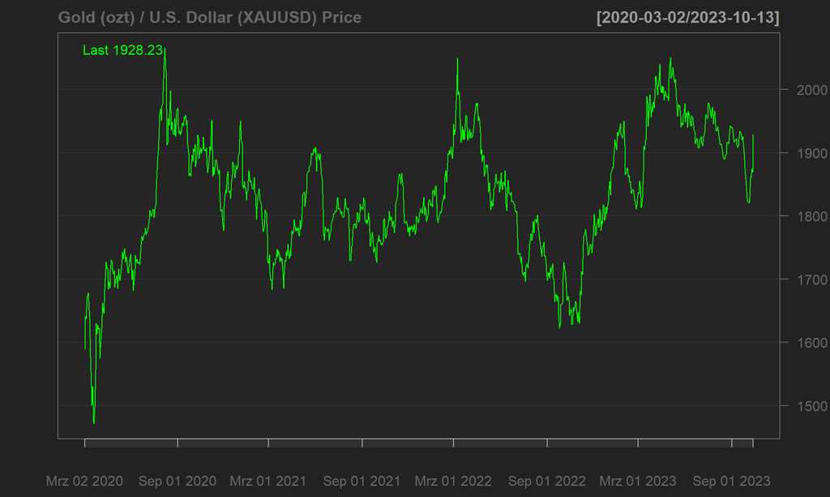

```r
chartSeries(data_xts$Close,name = 'Gold (ozt) / U.S. Dollar (XAUUSD) Price')
```

### Daily log return rate plot

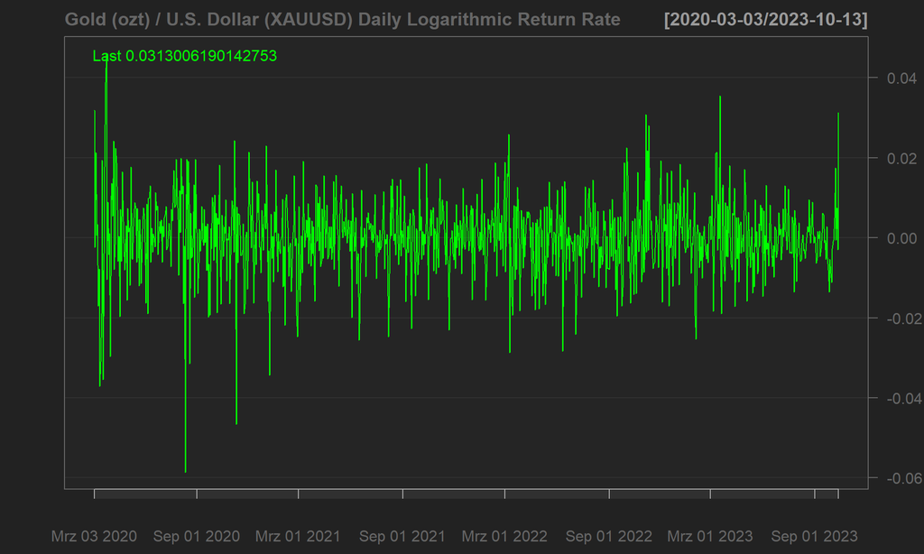

```r
chartSeries(data_xts$log_return_rate, name = 'Gold (ozt) / U.S. Dollar (XAUUSD) Daily Logarithmic Return Rate')
```

### Stationarity test

```r
adf.test(data_xts[-1,"log_return_rate"])
```

```
##
##  Augmented Dickey-Fuller Test
##
## data:  data_xts[-1, "log_return_rate"]
## Dickey-Fuller = -10.73, Lag order = 9, p-value = 0.01
## alternative hypothesis: stationary
```

### ACF plot

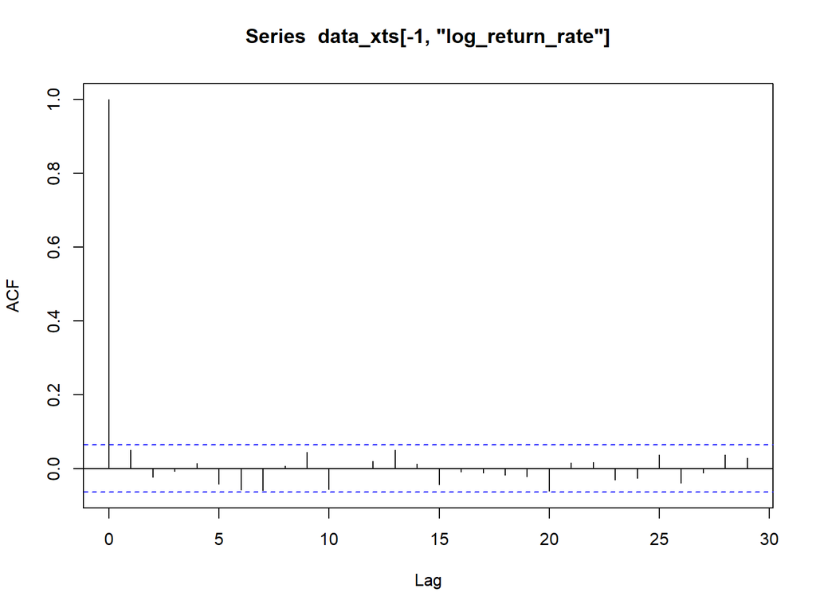

```r
acf(data_xts[-1,"log_return_rate"])
```

### PACF plot

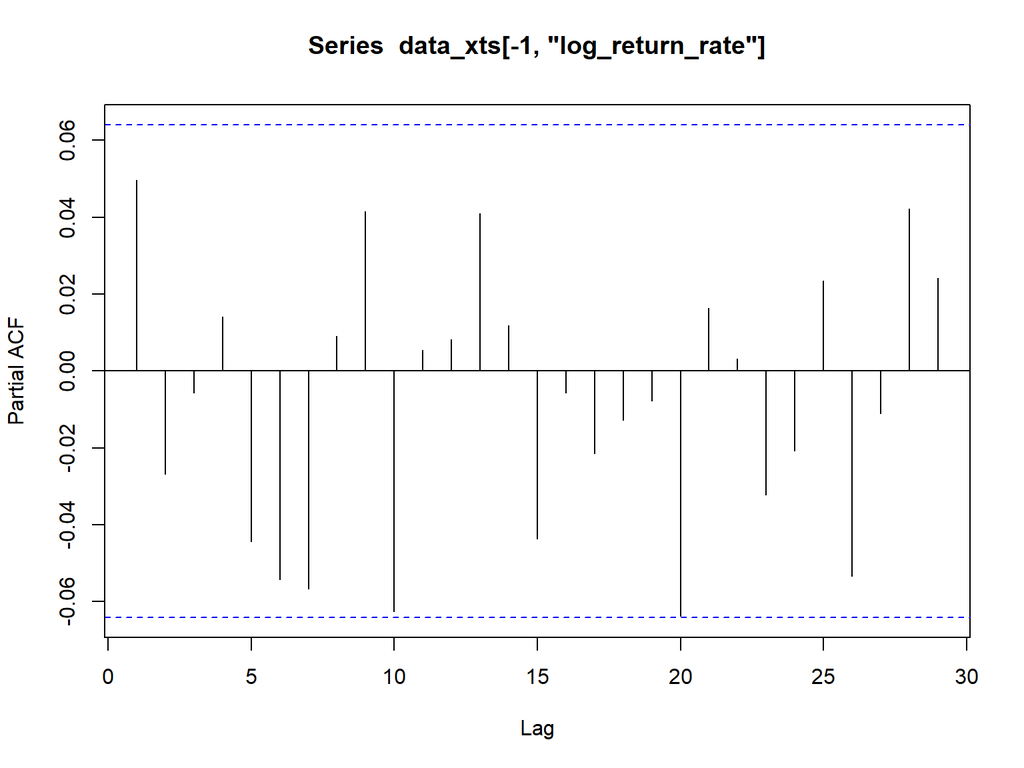

```r
pacf(data_xts[-1,"log_return_rate"])
```

## Modelling

### Specificiation of eGARCH model

```r
garch_model_spec <- ugarchspec(
  variance.model = list(model = "eGARCH", garchOrder = c(1, 1)),
  mean.model = list(armaOrder = c(0, 0)),
  distribution = "ged"
)
```

### Fitting the model

```r
garch_model_fit <- ugarchfit(
  spec = garch_model_spec,
  data = data_xts[-1, "log_return_rate"]
)
```

```r
garch_model_fit
```

```
##
## *---------------------------------*
## *          GARCH Model Fit        *
## *---------------------------------*
##
## Conditional Variance Dynamics
## -----------------------------------
## GARCH Model  : eGARCH(1,1)
## Mean Model   : ARFIMA(0,0,0)
## Distribution : ged
##
## Optimal Parameters
## ------------------------------------
##         Estimate  Std. Error  t value Pr(>|t|)
## mu      0.000417    0.000293   1.4268 0.153636
## omega  -0.547878    0.102808  -5.3292 0.000000
## alpha1  0.048246    0.027433   1.7586 0.078638
## beta1   0.941373    0.010934  86.0926 0.000000
## gamma1  0.171016    0.046992   3.6393 0.000273
## shape   1.223264    0.075497  16.2028 0.000000
##
## Robust Standard Errors:
##         Estimate  Std. Error  t value Pr(>|t|)
## mu      0.000417    0.000334   1.2502 0.211232
## omega  -0.547878    0.100774  -5.4367 0.000000
## alpha1  0.048246    0.028570   1.6887 0.091276
## beta1   0.941373    0.010592  88.8778 0.000000
## gamma1  0.171016    0.071249   2.4003 0.016384
## shape   1.223264    0.073369  16.6728 0.000000
##
## LogLikelihood : 3074.607
##
## Information Criteria
## ------------------------------------
##
## Akaike       -6.5639
## Bayes        -6.5328
## Shibata      -6.5639
## Hannan-Quinn -6.5520
##
```

[output cut: 43 more lines]

```
## Negative Sign Bias  0.4832 0.6291
## Positive Sign Bias  0.8385 0.4020
## Joint Effect        1.3806 0.7101
##
##
## Adjusted Pearson Goodness-of-Fit Test:
## ------------------------------------
##   group statistic p-value(g-1)
## 1    20     24.38      0.18199
## 2    30     32.09      0.31590
## 3    40     50.71      0.09914
## 4    50     54.57      0.27105
##
##
## Elapsed time : 0.5543642
```

#### The model exhibits very high value of beta and very low value of alpha. This can indicate that:

1. beta represents the long-term or memory component of the model. In this case, Gold (ozt) / U.S. Dollar (XAUUSD) logarithmic daily return rate exhibits a high degree of persistence in volatility, meaning that volatility tends to persist over time. In the context of daily stock return rates, this implies that once the market experiences volatility, it is likely to continue to be volatile over several subsequent days
2. alpha represents the short-term fluctuations. Based on very small value of this coefficient one could conclude that the model is not very responsive to recent volatility shocks
3. Since I’m using eGARCH, this model also contains gamma parameter. If this paramater is statistically significant and positive, one could conclude that there is a leverage effect which means that negative returns have greater impact on future volatility than positive returns.

### Additional plots

#### Red lines determine ~95% of the observations

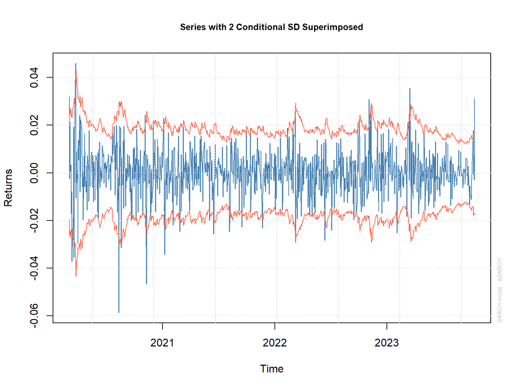

```r
plot(garch_model_fit,which=1)
```

#### Everything above green line is in the area of 1% highest return rates

#### Everything under red line is in the area of 1% lowest return rates

```
##
## please wait...calculating quantiles...
```

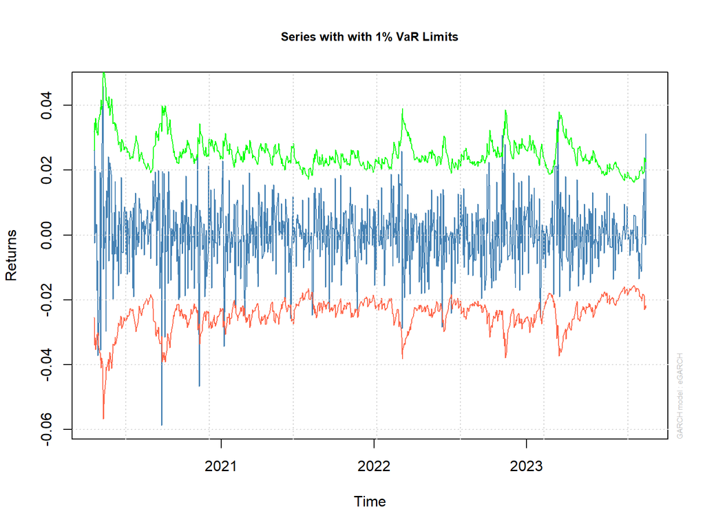

```r
plot(garch_model_fit,which=2)
```

#### This plot pictures how well conditional SD covers absolute values of the return rates.

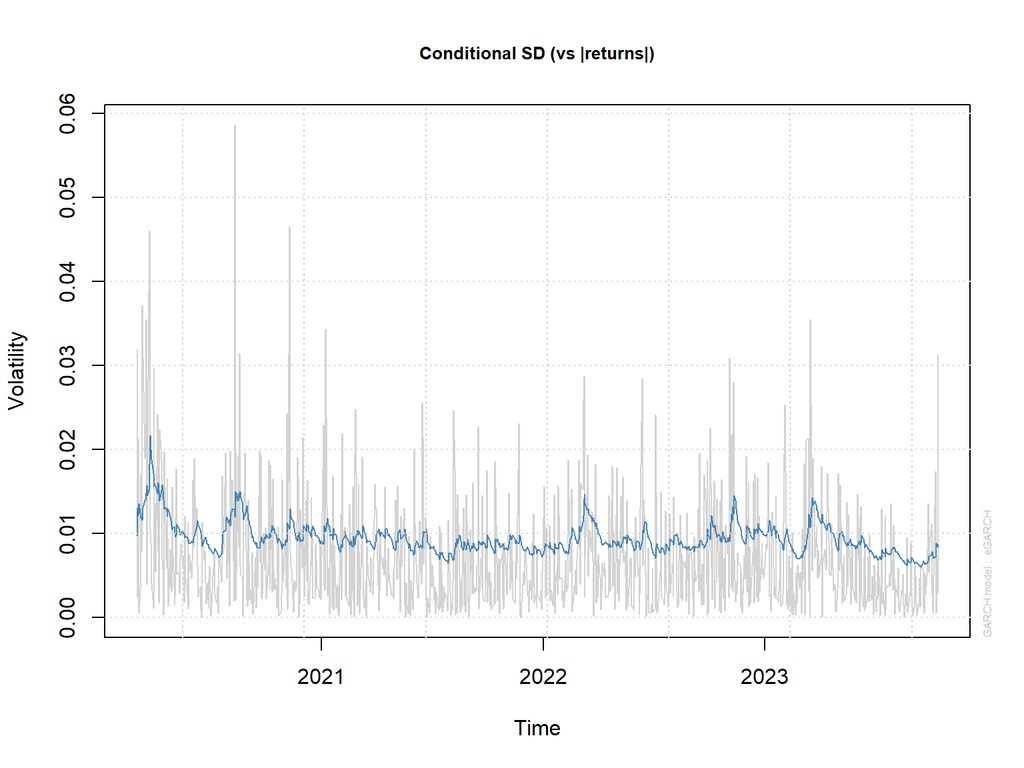

```r
plot(garch_model_fit,which=3)
```

#### ACF of Standardized Residuals

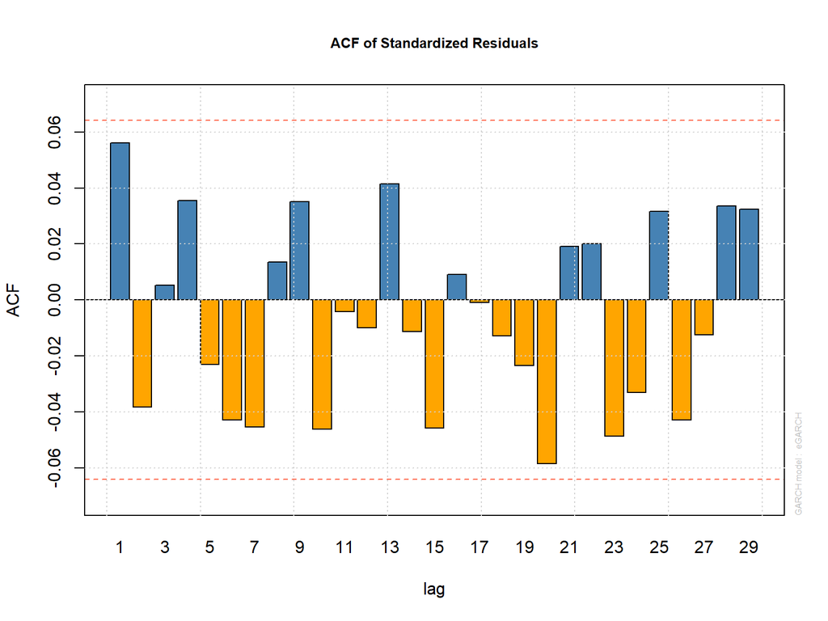

```r
plot(garch_model_fit,which=10)
```

#### ACF of Squared Standardized Residuals

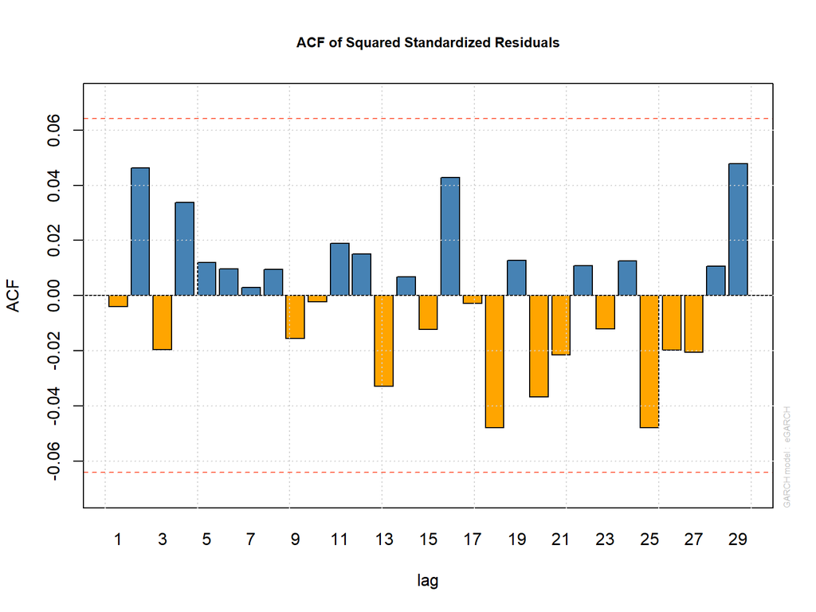

```r
plot(garch_model_fit,which=11)
```

#### Standardized Residuals density

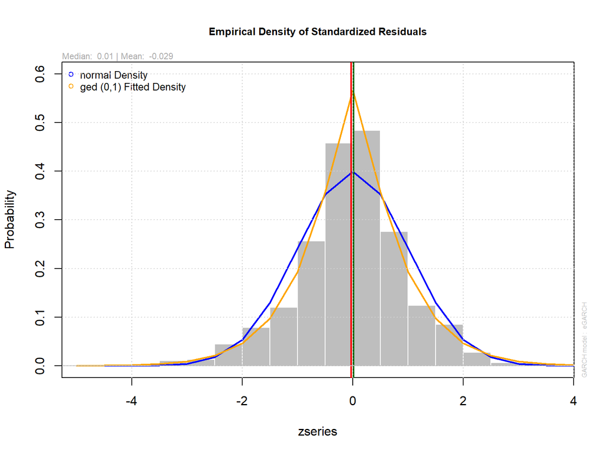

```r
plot(garch_model_fit,which=8)
```

### Prediction

```r
forc <- ugarchforecast(garch_model_fit)
```

### Forecast plot

#### Return rate prediction

```r
forc
```

```
##
## *------------------------------------*
## *       GARCH Model Forecast         *
## *------------------------------------*
## Model: eGARCH
## Horizon: 10
## Roll Steps: 0
## Out of Sample: 0
##
## 0-roll forecast [T0=2023-10-13]:
##         Series   Sigma
## T+1  0.0004174 0.01190
## T+2  0.0004174 0.01173
## T+3  0.0004174 0.01158
## T+4  0.0004174 0.01143
## T+5  0.0004174 0.01130
## T+6  0.0004174 0.01117
## T+7  0.0004174 0.01106
## T+8  0.0004174 0.01095
## T+9  0.0004174 0.01085
## T+10 0.0004174 0.01075
```

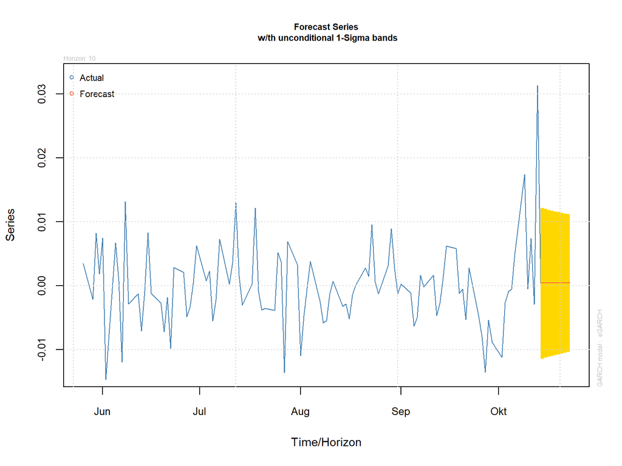

```r
plot(forc,which=1)
```

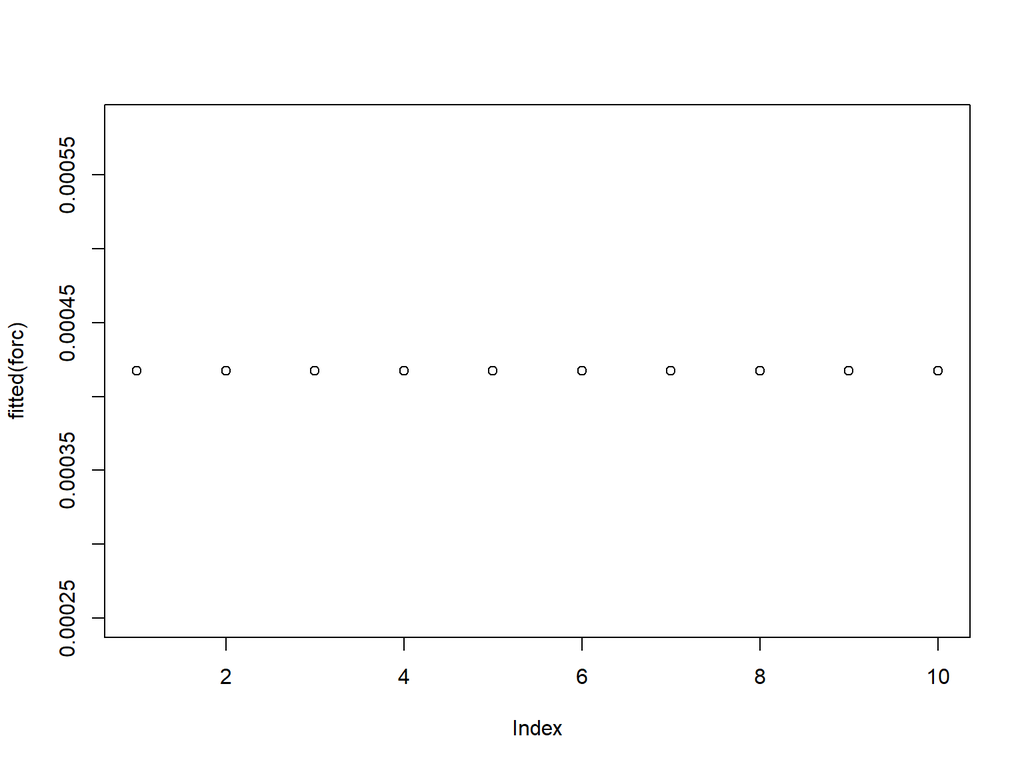

```r
plot(fitted(forc))
```

#### Sigma prediction

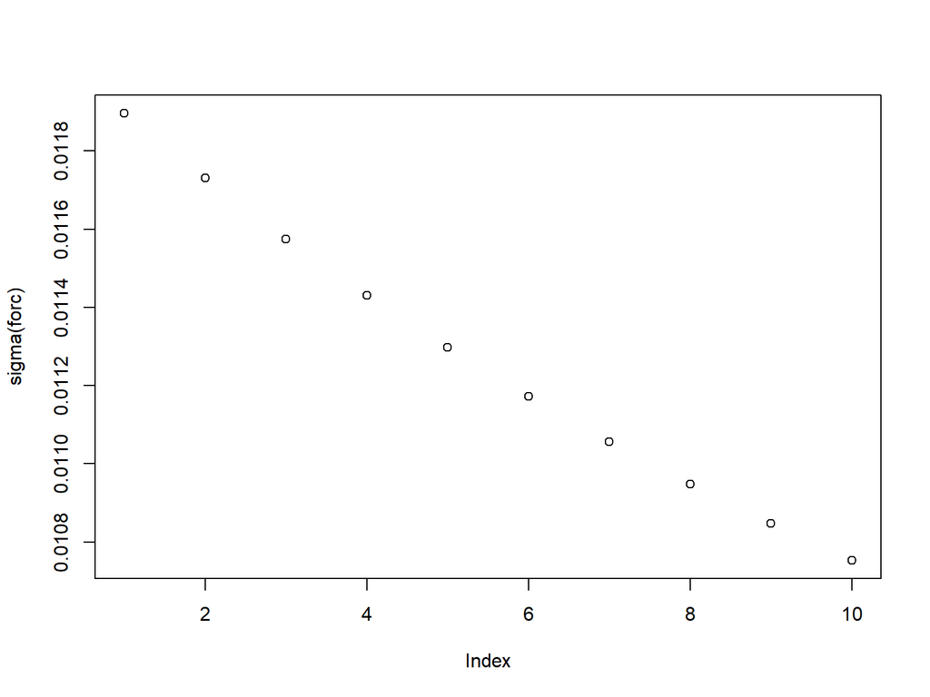

```r
plot(sigma(forc))
```